# Self-Driving Car Engineer Nanodegree

## Project: Build a Traffic Sign Recognition Classifier

In this notebook, a template is provided for you to implement your functionality in stages which is required to successfully complete this project. If additional code is required that cannot be included in the notebook, be sure that the Python code is successfully imported and included in your submission, if necessary. Sections that begin with **'Implementation'** in the header indicate where you should begin your implementation for your project. Note that some sections of implementation are optional, and will be marked with **'Optional'** in the header.

In addition to implementing code, there will be questions that you must answer which relate to the project and your implementation. Each section where you will answer a question is preceded by a **'Question'** header. Carefully read each question and provide thorough answers in the following text boxes that begin with **'Answer:'**. Your project submission will be evaluated based on your answers to each of the questions and the implementation you provide.

> **Note:** Code and Markdown cells can be executed using the **Shift + Enter** keyboard shortcut. In addition, Markdown cells can be edited by typically double-clicking the cell to enter edit mode.

## Step 1: Dataset Exploration

Visualize the German Traffic Signs Dataset. This is open ended, some suggestions include: plotting traffic signs images, plotting the count of each sign, etc. Be creative!

The pickled data is a dictionary with 4 key/value pairs:

- features -> the images pixel values, (width, height, channels)
- labels -> the label of the traffic sign
- sizes -> the original width and height of the image, (width, height)
- coords -> coordinates of a bounding box around the sign in the image, (x1, y1, x2, y2)

```python
# Load pickled data
import pickle
import csv
import os

# TODO: fill this in based on where you saved the training and testing data
training_file = 'traffic-signs-data/train.p'
testing_file = 'traffic-signs-data/test.p'

with open(training_file, mode='rb') as f:
    train = pickle.load(f)
with open(testing_file, mode='rb') as f:
    test = pickle.load(f)

X_train, y_train = train['features'], train['labels']
X_test, y_test = test['features'], test['labels']

# Make dictionary of sign names from CSV file
with open('signnames.csv', 'r') as csvfile:
    reader = csv.reader(csvfile)
    next(reader, None)  # skip the headers
    sign_names = dict((int(n),label) for n, label in reader)

cls_numbers, cls_names = zip(*sign_names.items())
```

```python
### To start off let's do a basic data summary.
# # TODO: number of training examples
n_train = len(y_train)

# # TODO: number of testing examples
n_test = len(y_test)

# # TODO: what's the shape of an image?
image_shape = X_train.shape[1:]

# # TODO: how many classes are in the dataset
n_classes = len(set(y_train))

print("Number of training examples =", n_train)
print("Number of testing examples =", n_test)
print("Image data shape =", image_shape)
print("Number of classes =", n_classes)
```

```
Number of training examples = 39209
Number of testing examples = 12630
Image data shape = (32, 32, 3)
Number of classes = 43
```

A helper function for plotting images and their labels is defined below. This is based in part, on the plot_images() function in the TensorFlow tutorials at https://github.com/Hvass-Labs/TensorFlow-Tutorials

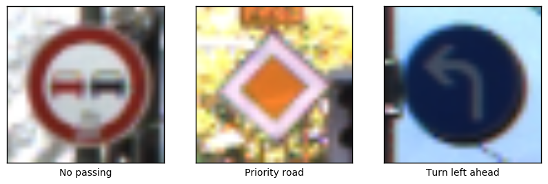

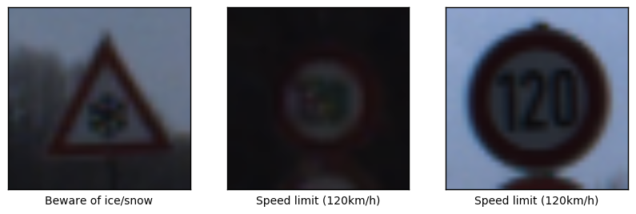

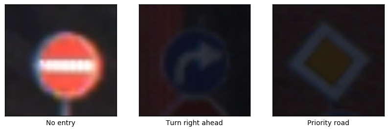

```python
### Data exploration visualization goes here.
### Feel free to use as many code cells as needed.
%matplotlib inline

import matplotlib
matplotlib.rcParams['figure.figsize'] = (10, 6)

import matplotlib.pyplot as plt
import random
import textwrap

def plot_images(images, cls_true, cls_pred=None, count=9, num_per_row=3, randomize=True):
    ctr = 0
    global sign_names

    if randomize:
        iterator = random.sample(range(len(images)), count)
    else:
        iterator = range(min(count, len(images)))

    for i in iterator:
        X, y_true = images[i,:], cls_true[i]

        if ctr % num_per_row == 0:
            # Create new row
            plt.figure()

        plt.subplot(1, num_per_row, (ctr % num_per_row) + 1)
        ax = plt.gca()
        plt.imshow(X)

        # Show the classes as the label on the x-axis.
        true_label = textwrap.fill(sign_names[y_true], 25)
        if cls_pred is not None:
            y_pred = cls_pred[i]

            pred_label = textwrap.fill(sign_names[y_pred], 25)
            ax.set_xlabel('True : {0} \n Pred: {1}'.format(true_label, pred_label))
        else:
            ax.set_xlabel(true_label)

        # Remove ticks from the plot.
        ax.set_xticks([])
        ax.set_yticks([])

        ctr += 1

plot_images(X_train, y_train)
plt.show()
```

```
Distribution of labels in training data
```

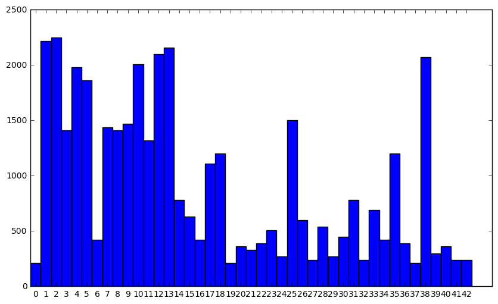

```python
from collections import Counter

ctr = Counter(sorted(y_train))
print('Distribution of labels in training data')
labels, values = zip(*(ctr.items()))

indexes = np.arange(len(labels))
width = 1

plt.bar(indexes, values, width)
plt.xticks(indexes + width * 0.5, labels)
plt.show()
```

## Step 2: Design and Test a Model Architecture

Design and implement a deep learning model that learns to recognize traffic signs. Train and test your model on the [German Traffic Sign Dataset](http://benchmark.ini.rub.de/?section=gtsrb&subsection=dataset).

There are various aspects to consider when thinking about this problem:

- Your model can be derived from a deep feedforward net or a deep convolutional network.
- Play around preprocessing techniques (normalization, rgb to grayscale, etc)
- Number of examples per label (some have more than others).
- Generate fake data.

Here is an example of a [published baseline model on this problem](http://yann.lecun.com/exdb/publis/pdf/sermanet-ijcnn-11.pdf). It's not required to be familiar with the approach used in the paper but, it's good practice to try to read papers like these.

### Implementation

Use the code cell (or multiple code cells, if necessary) to implement the first step of your project. Once you have completed your implementation and are satisfied with the results, be sure to thoroughly answer the questions that follow.

```python
import numpy as np
from PIL import Image
from sklearn.model_selection import train_test_split
from sklearn.preprocessing import LabelBinarizer
from sklearn.utils import resample
from tqdm import tqdm_notebook
from zipfile import ZipFile
import time
from datetime import timedelta
import math
import tensorflow as tf
```

```python
def normalize_color(image_data):
    """
    Normalize the image data with Min-Max scaling to a range of [0.1, 0.9]
    :param image_data: The image data to be normalized
    :return: Normalized image data
    """
    a = 0.1
    b = 0.9

    Xmin = 0.0
    Xmax = 255.0

    norm_img = np.empty_like(image_data, dtype=np.float32)

    norm_img = a + (image_data - Xmin)*(b-a)/(Xmax - Xmin)

#     norm_img = tf.image.random_flip_left_right(norm_img)
#     norm_img = tf.image.random_hue(norm_img, max_delta=0.05)
#     norm_img = tf.image.random_contrast(norm_img, lower=0.3, upper=1.0)
#     norm_img = tf.image.random_brightness(norm_img, max_delta=0.2)
#     norm_img = tf.image.random_saturation(norm_img, lower=0.0, upper=2.0)

    return norm_img

train_features = normalize_color(X_train)
test_features = normalize_color(X_test)
```

```python
# Turn labels into numbers and apply One-Hot Encoding
encoder = LabelBinarizer()
encoder.fit(y_train)
train_labels = encoder.transform(y_train)
test_labels = encoder.transform(y_test)

# Change to float32, so it can be multiplied against the features in TensorFlow, which are float32
train_labels = train_labels.astype(np.float32)
test_labels = test_labels.astype(np.float32)
is_labels_encod = True

print('Labels One-Hot Encoded')
```

```
Labels One-Hot Encoded
```

### Question 1

*Describe the techniques used to preprocess the data.*

**Answer:**

The images were normalized in all three channels. A new Python class `Dataset` was defined to allow accessing the dataset in batches of fixed size. This class makes sure it so that the data rolls over to the beginning if the end of the dataset is reached. Batching is important because of memory limitations that prevent working on the full data set at the same time, during training as well as testing.

Normalization is required in order to scale the gradients to a manageable level. RGB images are represented by numbers ranging from 0 to 255. This would require large numbers in the weight matrices of a neural network, with correspondingly high gradients. This would make training very difficult using gradient-descent methods. By normalizing the input to be on the order of ~1, this issue can be avoided.

### Question 2

*Describe how you set up the training, validation and testing data for your model. If you generated additional data, why?*

**Answer:** The dataset was augmented by introducing random rotations ($\pm$ 30 degrees) and translations ($\pm$ 2 pixels). This is done to make the network more robust towards such variations in the testing set. This also helps increase the number of data-points for those classes which have a comparatively low number of training data (show in Histogram in Step 1).

The dataset was then split into training and validation datasets using random sampling, with 5% of the features going into the latter. SKLearn's `train_test_split` was used for this. The validation set is used as a small testing sample to easily check the accuracy of the convnet during training, while possibly avoiding overfitting. By keeping the testing set completely separate from the training process, we can avoid accidentally overfitting the net to the testing set (by selecting different hyperparameters).

```python
### Generate data additional (if you want to!)
### and split the data into training/validation/testing sets here.

from scipy.misc import imrotate
class Dataset():
    """
    A class that provides an unlimited supply of batched data from a given dataset
    """
    def __init__(self, features, labels):
        self.features = features
        self.labels = labels
        self.length = len(features)
        self.reset()

    def reset(self):
        self.ctr = 0

    def next_batch(self, batch_size):
        """
        Returns an a batch of data, resetting to beginning any time it reaches the end
        """
        indices = np.arange(self.ctr, self.ctr+batch_size) % self.length
        self.ctr += batch_size
        self.ctr = self.ctr % len(self.features)

        return self.features[indices], self.labels[indices]

def rand_rotate(image, degrees=30):
    rotated = imrotate(image, np.random.uniform(-degrees, +degrees))
    return rotated

def rand_translate(image, shift_px=2):
    out = np.zeros_like(image)
    shift = int(np.random.uniform(-shift_px, +shift_px))
    left = max(0, -shift)
    right= min(image.shape[1], image.shape[1]-shift)
    left_out = max(0, shift)
    right_out = min(image.shape[1], image.shape[1]+shift)

    shift = int(np.random.uniform(-shift_px, +shift_px))
    top = max(0, -shift)
    btm = min(image.shape[1], image.shape[1]-shift)
    top_out = max(0, shift)
    btm_out = min(image.shape[1], image.shape[1]+shift)
    out[top_out:btm_out,left_out:right_out] = image[top:btm,left:right]

    return out

# Add perturbed datasets -- rotation (+/- 15 deg) and translation(-2,2 px) ( no scale(0.9-1.1) )
new_features = []
new_labels = []

for img, lbl in tqdm_notebook(zip(train_features, train_labels), unit=' images'):
    rot = rand_rotate(img)
    new_features.append(rot)
    new_labels.append(lbl)

    trn = rand_translate(img)

    new_features.append(trn)
    new_labels.append(lbl)

train_features = np.concatenate((train_features, np.array(new_features)))
train_labels = np.concatenate((train_labels, np.array(new_labels)))

# Get randomized datasets for training and validation
train_features, valid_features, train_labels, valid_labels = train_test_split(
    train_features,
    train_labels,
    test_size=0.05,
    random_state=0xdeadbeef)

print('Training features and labels randomized and split.')
```

```
Training features and labels randomized and split.
```

```python
train_data = Dataset(train_features, train_labels)
test_data = Dataset(test_features, test_labels)
valid_data = Dataset(valid_features, valid_labels)
```

### Question 3

*What does your final architecture look like? (Type of model, layers, sizes, connectivity, etc.) For reference on how to build a deep neural network using TensorFlow, see Deep Neural Network in TensorFlow from the classroom.*

#### Convolutional Neural Network

### **Answer:**

The final architecture has five convolutional layers and two fully connected layers. The convolutional layers has depths of 16, 32, 64, 128 and 256 respectively while the two fully connected layers has 1024 and 512 neurons.

Different configurations were tested and the following results were obtained:

**[Conv5x5]-[Conv5x5]-MaxPool-Dropout-[Conv5x5]-MaxPool-[Conv3x3]-MaxPool-Dropout-[Conv3x3]-MaxPool-FC1-FC2** => 96.62% after 45k iterations of training

```python
tf.reset_default_graph()    ## MANDATORY !!!
### Define your architecture here.
layer_width = {
    'layer_1': 16,
    'layer_2': 32,
    'layer_3': 64,
    'layer_4': 128,
    'layer_5': 256,

    'fc1': 1024,
    'fc2': 512
}

# Store layers weight & bias
weights = {
    'layer_1': tf.Variable(tf.truncated_normal(
        [5, 5, 3, layer_width['layer_1']]), name='W_L1'),
    'layer_2': tf.Variable(tf.truncated_normal(
        [5, 5, layer_width['layer_1'], layer_width['layer_2']], stddev=0.005), name='W_L2'),
    'layer_3': tf.Variable(tf.truncated_normal(
        [5, 5, layer_width['layer_2'], layer_width['layer_3']], stddev=0.005), name='W_L3'),
    'layer_4': tf.Variable(tf.truncated_normal(
        [3, 3, layer_width['layer_3'], layer_width['layer_4']], stddev=0.05), name='W_L4'),
    'layer_5': tf.Variable(tf.truncated_normal(
        [3, 3, layer_width['layer_4'], layer_width['layer_5']], stddev=0.05), name='W_L5'),

    'fc1': tf.Variable(tf.truncated_normal(
        [1024, layer_width['fc1']], stddev=0.05), name='W_F1'),
    'fc2': tf.Variable(tf.truncated_normal(
        [layer_width['fc1'], layer_width['fc2']], stddev=0.05), name='W_F2'),
    'out': tf.Variable(tf.truncated_normal(
        [layer_width['fc2'], n_classes], stddev=0.05))
}
biases = {
    'layer_1': tf.Variable(tf.zeros(layer_width['layer_1']), name='b_L1'),
    'layer_2': tf.Variable(tf.zeros(layer_width['layer_2']), name='b_L2'),
    'layer_3': tf.Variable(tf.zeros(layer_width['layer_3']), name='b_L3'),
    'layer_4': tf.Variable(tf.zeros(layer_width['layer_4']), name='b_L4'),
    'layer_5': tf.Variable(tf.zeros(layer_width['layer_5']), name='b_L5'),
    'fc1': tf.Variable(tf.zeros(layer_width['fc1']), name='b_F1'),
    'fc2': tf.Variable(tf.zeros(layer_width['fc2']), name='b_F2'),
    'out': tf.Variable(tf.zeros(n_classes))
}

def conv2d(x, W, b, strides=1):
    x = tf.nn.conv2d(x, W, strides=[1, strides, strides, 1], padding='SAME')
    x = tf.nn.bias_add(x, b)
    return tf.nn.relu(x)


def maxpool2d(x, k=2):
    return tf.nn.max_pool(
        x,
        ksize=[1, k, k, 1],
        strides=[1, k, k, 1],
        padding='SAME')

# Create model
def conv_net(x, weights, biases, keep_prob):
    # Layer 1
    conv1 = conv2d(x, weights['layer_1'], biases['layer_1'])

    # Layer 2
    conv2 = conv2d(conv1, weights['layer_2'], biases['layer_2'])
    conv2 = tf.nn.dropout(conv2, keep_prob)

    # Layer 3
    conv3 = conv2d(conv2, weights['layer_3'], biases['layer_3'])
#     conv3 = maxpool2d(conv3)

    # Layer 4
    conv4 = conv2d(conv3, weights['layer_4'], biases['layer_4'], strides=2)
    conv4 = maxpool2d(conv4)
    conv4 = tf.nn.dropout(conv4, keep_prob)

    # Layer 5
    conv5 = conv2d(conv4, weights['layer_5'], biases['layer_5'], strides=2)
    conv5 = maxpool2d(conv5)
#     print(conv5)

    # Fully connected layer
    # Reshape conv3 output to fit fully connected layer input
    fc1 = tf.reshape(
        conv5,
        [-1, weights['fc1'].get_shape().as_list()[0]])

    fc1 = tf.add(tf.matmul(fc1, weights['fc1']), biases['fc1'])
    fc1 = tf.nn.relu(fc1)

    fc2 = tf.add(tf.matmul(fc1, weights['fc2']), biases['fc2'])
    fc2 = tf.nn.relu(fc2)

    # Output Layer - class prediction
    out = tf.add(tf.matmul(fc2, weights['out']), biases['out'], name='logits')
    return out

# tf Graph input
X = tf.placeholder("float", [None, image_shape[0], image_shape[1], image_shape[2]], name='X')
y_true = tf.placeholder("float", [None, n_classes], name='y')
y_true_cls = tf.argmax(y_true, dimension=1)
dropout_keep_prob = tf.placeholder('float', name='keep_prob')

# Create the ConvNet
train_logits = conv_net(X, weights, biases, dropout_keep_prob)

# Compute predicted class
y_pred = tf.nn.softmax(train_logits)
y_pred_cls = tf.argmax(y_pred, dimension=1, name='y_pred_cls')

correct_prediction = tf.equal(y_pred_cls, y_true_cls)
accuracy = tf.reduce_mean(tf.cast(correct_prediction, tf.float32))

# # Feed dicts for training, validation, and test session
# train_feed_dict = {X: train_features, y_true: train_labels}
# valid_feed_dict = {X: valid_features, y_true: valid_labels}
# test_feed_dict = {X: test_features, y_true: test_labels}
print('X: ',X.name)
print('y_true: ',y_true.name)
print('y_pred_cls: ',y_pred_cls.name)
print('dropout_keep_prob: ',dropout_keep_prob.name)
```

```
X:  X:0
y_true:  y:0
y_pred_cls:  y_pred_cls:0
dropout_keep_prob:  keep_prob:0
```

```python
def train_model(session, optimizer, cost, model, train_data, num_iterations, save_best=True, valid_data=None, batch_size=256, keep_prob=0.5):
    iter_pbar = tqdm_notebook(range(num_iterations), unit=' iterations')

    if save_best:
        global saver, save_dir

    best_validation_accuracy = 0.0
    last_improvement = 0
    require_improvement = 1000

    save_path = save_dir + 'best_validation'

    for ctr in iter_pbar:
        batch_X, batch_y = train_data.next_batch(batch_size)

        feed_dict_train = {X: batch_X, y_true: batch_y, dropout_keep_prob: keep_prob}
        _, c = session.run([optimizer, cost], feed_dict=feed_dict_train)

        if save_best and ((ctr % 1000 == 0) or (ctr == (num_iterations - 1))):
            train_acc = session.run(accuracy, feed_dict={X: batch_X, y_true: batch_y, dropout_keep_prob: 1.0})
            valid_acc = get_validation_accuracy(session, model)

            # If validation accuracy is an improvement over best-known.
            if valid_acc > best_validation_accuracy:
                # Update the best-known validation accuracy.
                best_validation_accuracy = valid_acc

                # Set the iteration for the last improvement to current.
                last_improvement = ctr

                # Save all variables of the TensorFlow graph to file.
                saver.save(sess=session, save_path=save_path)

                # A string to be printed below, shows improvement found.
                improved_str = '*'
            else:
                # Shows that no improvement was found.
                improved_str = ''
#             # If no improvement found in the required number of iterations.
#             if ctr - last_improvement > require_improvement:
#                 print("No improvement found in a while, stopping optimization.")

#                 # Break out from the for-loop.
#                 break

        iter_pbar.set_description('c={0:>6.4}, train_acc={1:>6.2%}, valid_acc={2:>6.2%}{3}, best={4:>6.2%}'.format(c,
                                                                                          train_acc,
                                                                                          valid_acc,
                                                                                          improved_str,
                                                                                          best_validation_accuracy))
    print("Last improvement at "+str(last_improvement+1))

def get_accuracy(session, model, data, batch_size=421):
    # Number of images in the test-set.
    num_test = data.length

    # Allocate an array for the predicted classes which
    # will be calculated in batches and filled into this array.
    cls_pred = np.zeros(shape=num_test, dtype=np.int)

    i = 0
    while i < num_test:
        # The ending index for the next batch is denoted j.
        j = min(i + batch_size, num_test)

        # Get the images from the test-set between index i and j.
        batch_images = data.features[i:j, :]

        # Get the associated labels.
        batch_labels = data.labels[i:j, :]

        # Create a feed-dict with these images and labels.
        feed_dict = {X: batch_images,
                     y_true: batch_labels,
                     dropout_keep_prob: 1.0}

        # Calculate the predicted class using TensorFlow.
        cls_pred[i:j] = session.run(model, feed_dict=feed_dict)

        # Set the start-index for the next batch to the
        # end-index of the current batch.
        i = j


    # Convenience variable for the true class-numbers of the test-set.
    cls_true = np.argmax(data.labels, axis=1)
    # Create a boolean array whether each image is correctly classified.
    correct = np.equal(cls_true, cls_pred)

    # Calculate the number of correctly classified images.
    # When summing a boolean array, False means 0 and True means 1.
    correct_sum = sum(correct)

    # Classification accuracy is the number of correctly classified
    # images divided by the total number of images in the test-set.
    acc = float(correct_sum) / num_test
    return acc, cls_pred

def get_validation_accuracy(session, model):
    valid_acc, _ = get_accuracy(session, model, valid_data, batch_size=256)
    return valid_acc

def get_train_accuracy(session, model):
    train_acc, _ = get_accuracy(session, model, train_data, batch_size=256)
    return train_acc

def print_accuracy():
    train_acc = get_train_accuracy(session, y_pred_cls)
    valid_acc = get_validation_accuracy(session, y_pred_cls)

    print('Training Accuracy : %.2f %%' % (train_acc*100))
    print('Validation Accuracy : %.2f %%' % (valid_acc*100))

def print_test_accuracy():
    test_acc, _ = get_accuracy(session, y_pred_cls, test_data, batch_size=421)
    print('Test Accuracy : %.2f %%' % (test_acc*100))

def plot_wrong_tests():
    test_acc, cls_pred = get_accuracy(session, y_pred_cls, test_data, batch_size=421)
    cls_true = np.argmax(test_data.labels, axis=1)

    wrong = np.not_equal(cls_true, cls_pred)

    plot_images(test_data.features[wrong], cls_true[wrong], cls_pred[wrong])
```

### Question 4

*How did you train your model? (Type of optimizer, batch size, epochs, hyperparameters, etc.)*

**Answer:**

The `get_accuracy` function performs a similar batched process for computing the accuracy of the model against a given dataset. This batching is again necessary due to memory limitations. The `plot_wrong_tests` method shows a sample of wrongly classified images from the test dataset. This is useful for analysis.

```python
# Parameters
learning_rate = 1e-4
batch_size = 64

global_step = tf.Variable(0, name='global_step', trainable=False)

# Define loss and optimizer
cost = tf.reduce_mean(tf.nn.softmax_cross_entropy_with_logits(train_logits, y_true))
optimizer = tf.train.AdamOptimizer(learning_rate=learning_rate).minimize(cost, global_step=global_step)


# This is evaluated later when checking training accuracy
correct_prediction = tf.equal(y_pred_cls, y_true_cls)
accuracy = tf.reduce_mean(tf.cast(correct_prediction, tf.float32), name='accuracy')

tf.add_to_collection('train_ops', optimizer)
tf.add_to_collection('train_ops', cost)
tf.add_to_collection('model', y_pred_cls)
tf.add_to_collection('accuracy', accuracy)

tf.add_to_collection('logits', train_logits)
tf.add_to_collection('inputs', X)
tf.add_to_collection('inputs', y_true)
tf.add_to_collection('inputs', dropout_keep_prob)
```

```python
session = tf.Session()
```

```python
saver = tf.train.Saver()
save_dir = 'checkpoints/'
```

```python
batch_size=64
session.run(tf.initialize_all_variables())
train_model(session, optimizer, cost, y_pred_cls, train_data, 10, batch_size)
print_accuracy()
```

```
Last improvement at 10
Training Accuracy : 5.44 %
Validation Accuracy : 5.22 %
```

```python
# Run 1000 iterations
train_model(session, optimizer, cost, y_pred_cls, train_data, 990, batch_size)
saver.save(session, save_dir+'mdl3', global_step=global_step)
print_accuracy()
```

```
Last improvement at 990
Training Accuracy : 34.37 %
Validation Accuracy : 34.48 %
```

```python
# Run 10000 iterations
train_model(session, optimizer, cost, y_pred_cls, train_data, 9000, batch_size)
print_accuracy()
print_test_accuracy()
saver.save(session, save_dir+'mdl3', global_step=global_step)
```

[output not shown]

```
'checkpoints/mdl3-10000'
```

```python
# Run 50000 iterations
train_model(session, optimizer, cost, y_pred_cls, train_data, 40000, batch_size)
test_acc, _ = get_accuracy(session, y_pred_cls, test_data, batch_size=421)
saver.save(session, save_dir+'mdl3'+str(int(test_acc*100)), global_step=global_step)
print_accuracy()
```

```
Last improvement at 40000
Training Accuracy : 100.00 %
Validation Accuracy : 99.74 %
```

```python
# saver.save(session, save_dir+'mdl3-96.79', global_step=42000)
train_model(session, optimizer, cost, y_pred_cls, train_data, 50000, batch_size)
test_acc, _ = get_accuracy(session, y_pred_cls, test_data, batch_size=421)
saver.save(session, save_dir+'mdl3'+str(int(test_acc*100)), global_step=global_step)
print_accuracy()
print_test_accuracy()
```

```
Last improvement at 13001
Training Accuracy : 100.00 %
Validation Accuracy : 99.80 %
Test Accuracy : 96.59 %
```

```python
# Another 20000 iterations
train_model(session, optimizer, cost, y_pred_cls, train_data, 30000, batch_size)
test_acc, _ = get_accuracy(session, y_pred_cls, test_data, batch_size=421)
saver.save(session, save_dir+'mdl3'+str(int(test_acc*100)), global_step=global_step)
print_accuracy()
print_test_accuracy()
```

```
Last improvement at 10001
Training Accuracy : 100.00 %
Validation Accuracy : 99.74 %
Test Accuracy : 96.63 %
```

```
Iterations :  140001
Test Accuracy : 97.09 %
```

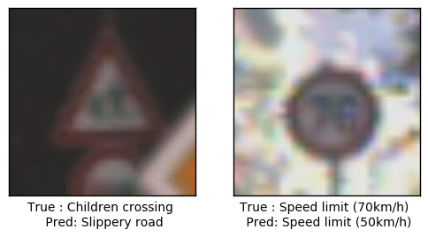

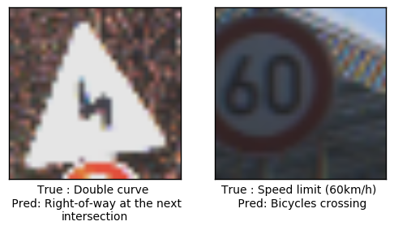

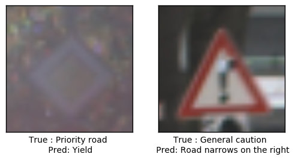

```python
# saver=tf.train.Saver(var_list=[y_pred_cls], reshape=True)
session = tf.Session()
saver = tf.train.Saver()
save_dir = 'checkpoints/'
# saver = tf.train.import_meta_graph(save_dir + 'mdl3-97.70-100000.meta')
saver.restore(sess=session, save_path=save_dir + 'mdl3-97.09-140001')
# g = tf.get_default_graph()

# saver.save(session, save_dir+'mdl3-97.09', global_step=global_step)
# saver.restore(sess=session, save_path=save_dir + 'mdl3-97.02-130000')
# saver.restore(sess=session, save_path=save_dir + 'best_validation')
# print_accuracy()
print('Iterations : ',global_step.eval(session=session))
print_test_accuracy()
plot_wrong_tests()
plt.show()
```

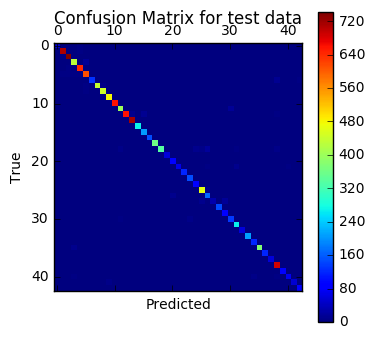

```python
# Source: https://github.com/Hvass-Labs/TensorFlow-Tutorials/
from sklearn.metrics import confusion_matrix

cls_true = np.argmax(test_data.labels, axis=1)
test_acc, cls_pred = get_accuracy(session, y_pred_cls, test_data, batch_size=421)

# Get the confusion matrix using sklearn.
cm = confusion_matrix(y_true=cls_true,
                      y_pred=cls_pred)

# # Print the confusion matrix as text.
# print(cm)

# Plot the confusion matrix as an image.
plt.matshow(cm)

# Make various adjustments to the plot.
plt.colorbar()
# tick_marks = np.arange(n_classes)
# plt.xticks(tick_marks, range(n_classes))
# plt.yticks(tick_marks, range(n_classes))
plt.xlabel('Predicted')
plt.ylabel('True')
plt.title('Confusion Matrix for test data')

# Ensure the plot is shown correctly with multiple plots
# in a single Notebook cell.
plt.show()
```

```python
session.close()
```

### Question 5

*What approach did you take in coming up with a solution to this problem?*

**Answer:**

First, I used a simple linear classifier on the dataset (this is not in the notebook). This was primarily done to make sure that my image pre-processing as well as my tensorflow setup was working. In fact, when I first tried blindly implementing a CNN, it didn't work out so well. Implementing the linear classifier helped me find a few bugs in my preprocessing step. The linear classifier got a test accuracy of around 70%.

The best I got was 97.70%, however that trained model is no longer accessible as I am unable to restore the checkpoint file. This might have been because of not resetting the TF graph each time I initialized the TF variables and placeholders. The internal variable names in the checkpoint file do not match the ones I get when I initialize the graph myself and hence it is no longer usable. However, my current best solution is very close to this.

The images that the model fails to classify properly are mostly ones that are very blurred and unclear to the human eye as well. There are one or two others that the model struggles with even if it is clear. These will be discussed in the next section.

## Step 3: Test a Model on New Images

Take several pictures of traffic signs that you find on the web or around you (at least five), and run them through your classifier on your computer to produce example results. The classifier might not recognize some local signs but it could prove interesting nonetheless.

You may find `signnames.csv` useful as it contains mappings from the class id (integer) to the actual sign name.

### Implementation

Use the code cell (or multiple code cells, if necessary) to implement the first step of your project. Once you have completed your implementation and are satisfied with the results, be sure to thoroughly answer the questions that follow.

```
9  images loaded and processed.
```

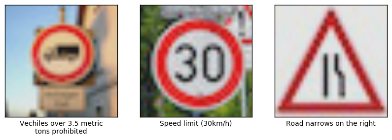

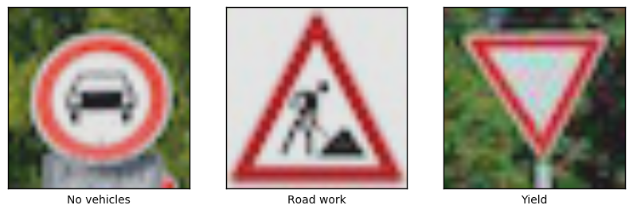

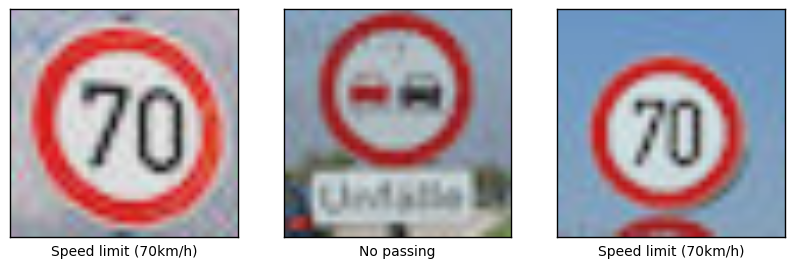

```python
### Load the images and plot them here.
### Feel free to use as many code cells as needed.
from scipy.ndimage import imread
def load_images(folder):
    # Make dictionary of sign names from CSV file
    with open(folder+'/imagedata.csv', 'r') as csvfile:
        reader = csv.reader(csvfile)
        image_files, labels = zip(*[(imgfile,int(label)) for imgfile, label in reader])

    X_extra = np.zeros((len(labels), 32, 32, 3), dtype=np.float32)
    for i, img_file in enumerate(image_files):
        X_extra[i] = imread(folder+'/'+img_file, mode='RGB')

    features = normalize_color(X_extra)

    return features, labels

extra_features, y_extra = load_images('extra-data')

# One-Hot encode labels
encoder = LabelBinarizer()
encoder.fit(cls_numbers)
extra_labels = encoder.transform(y_extra)

print(len(extra_features),' images loaded and processed.')

extra_data = Dataset(extra_features, extra_labels)

extra_labels_cls = np.argmax(extra_labels, axis=1)
plot_images(extra_features, extra_labels_cls, count=9, num_per_row=3)
plt.show()
```

### Question 6

*Choose five candidate images of traffic signs and provide them in the report. Are there any particular qualities of the image(s) that might make classification difficult? It would be helpful to plot the images in the notebook.*

```python
# Load the trained model from disk
save_dir = 'checkpoints/'

file_name = save_dir+'mdl3-97.09-140001'
# file_name = save_dir+'mdl3-97.02-130000'
meta_name = file_name+'.meta'

tf.reset_default_graph()
session = tf.Session()

saver = tf.train.import_meta_graph(meta_name)
saver.restore(sess=session, save_path=file_name)

model = tf.get_collection('model')[0]
X, y_true, dropout_keep_prob = tf.get_collection('inputs')
logits = tf.get_collection('logits')[0]
y_pred = tf.nn.softmax(logits)
top5 = tf.nn.top_k(y_pred, 5)
```

```python
extra_acc, cls_pred = get_accuracy(session, model, extra_data, batch_size=9)

y_pred_val, top5_val = session.run([y_pred, top5], feed_dict={X: extra_features, y_true: extra_labels, dropout_keep_prob:1.0})
# plot_images(extra_features, extra_labels_cls, cls_pred, count=9, num_per_row=3, randomize=False)
# plt.show()
```

**Answer:**

The model has varying success when it comes to classifying external images. It is able to correctly classify 6 out of 9 sample images. The three image it classified wrong (images 1, 3 and 7) are shown below:

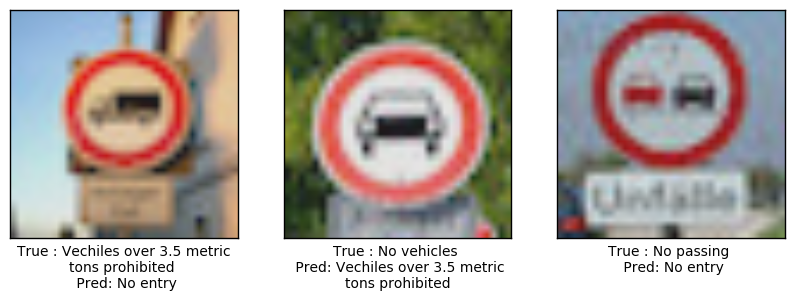

```python
wrong = np.not_equal(extra_labels_cls, cls_pred)
plot_images(extra_features[wrong], extra_labels_cls[wrong], cls_pred[wrong], randomize=False)
plt.show()
```

These images do seem like they should be easy enough to identify. They are very clear. The confusion in the second image is more reasonable since the outline of the car is a little dim compared to the central portion which is about the same shape as a truck. This could be caused due to an unbalanced training data-set. The distribution of labels in the training data was plotted earlier in this document.

It can be seen that there are very few datapoints for class number 16 (Vehicles over 3.5 tons prohibited), 15 (No vehicles) as compared to some other classes. However, this still doesn't explain why the "No passing" (class 9) was mis-identified as "No entry" (class 17). Later analysis showed that for this last case, "No passing" was assigned a 20% probability (Question 8).

### Question 7

*Is your model able to perform equally well on captured pictures or a live camera stream when compared to testing on the dataset?*

**Answer:**

Doing the same process on a live stream would also require some method to crop out the area of interest out of the image or modifying the convnet to be able to process variable sized images. The data-pipleline would require a proper feature-detection method, possibly a neural net or CV algorithm that detects the coordinates of traffic signs within a bigger image. After proper feature-detection, this convnet should be able to classify any traffic signs that show up in the video stream with good accuracy.

### Question 8

*Use the model's softmax probabilities to visualize the **certainty** of its predictions, [`tf.nn.top_k`](https://www.tensorflow.org/versions/r0.11/api_docs/python/nn.html#top_k) could prove helpful here. Which predictions is the model certain of? Uncertain? If the model was incorrect in its initial prediction, does the correct prediction appear in the top k? (k should be 5 at most)*

**Answer:** The softmax probabilities of the predictions on the 9 test images are shown below. The image classes are along the x-axis and the probability is on the y-axis. Each line denotes the results from one image and the star shows the probability assigned to the true class for that image. Dotted lines indicate an image that was mis-classified.

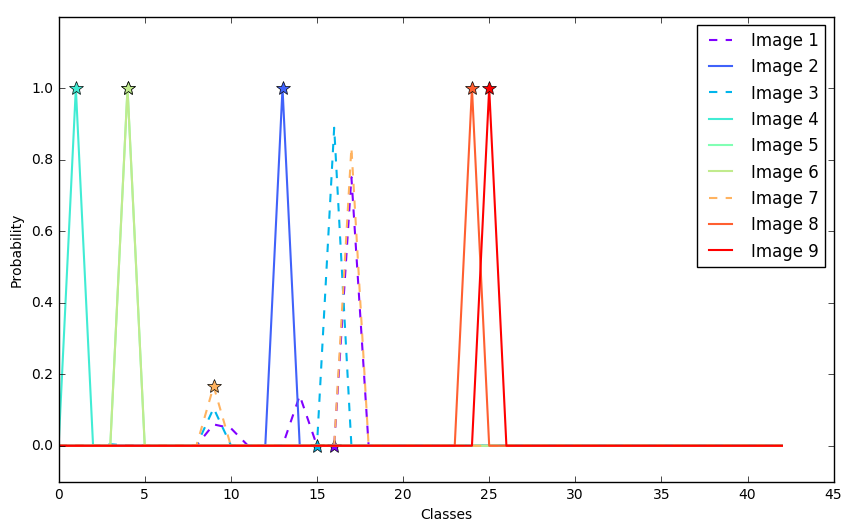

```python
### Visualize the softmax probabilities here.
### Feel free to use as many code cells as needed.
import matplotlib.cm as cm

colors = iter(cm.rainbow(np.linspace(0, 1, len(y_pred_val))))

plt.figure()
plt.hold(True)
args = {'linewidth': 1.5}
legends = []
for i, (softm_prob, color) in enumerate(zip(y_pred_val, colors)):
    # Dotted line = incorrect prediction
    args['color'] = color
    if wrong[i]:
        args['linestyle'] = 'dashed'
    else:
        args['linestyle'] = 'solid'
    line = plt.plot(softm_prob, **args, label='Image '+str(i+1))
    true_label = extra_labels_cls[i]
    plt.plot(true_label, softm_prob[true_label], '*', markersize=10, label=None, **args)
#     legends.append())

plt.legend()
plt.ylim(-0.1, 1.2)
plt.xlabel('Classes')
plt.ylabel('Probability')
plt.show()
```

```python
np.set_printoptions(suppress=True, precision=4)
print('Top 5 labels for the wrongly classified images:')
print(top5_val.indices[wrong,:])
print('True labels')
print(extra_labels_cls[wrong][:,np.newaxis])
```

```
Top 5 labels for the wrongly classified images:
[[17  9 14 10 29]
 [16  9  3 10 15]
 [17  9 16 10 13]]
True labels
[[16]
 [15]
 [ 9]]
```

The stars in the plot denote the probability assigned to the true category. The model seems to be very confident and opinionated with very sharp peaks in probability.

In the case of images 3 and 7, the right label is still in the top-5 choices even though the peak probability is assigned to the wrong label. In fact, the model even assigns a non-trivial probability (20%) to the right label in case of image 7. It was confused between the "No passing" and "No entry" signs.

However, in the case of image 1, the right class ("Vehicles over 3.5 ton prohibited") is not among the top-5 candidates predicted by the model.

### Question 9

*If necessary, provide documentation for how an interface was built for your model to load and classify newly-acquired images.*

**Answer:**

The true labels for the images was stored in a CSV files with each line containing one filename and the corresponding class number. The `load_images` function reads the CSV, loads the image files and normalizes them. The labels are then one-hot encoded for passing into the classifier.

The contents of the extra-data folder and the CSV file containing the metadata are shown below.

```python
import os
print('Files in extra-data:')
print(os.listdir('extra-data/'))
print('\nContents of imagedata.csv:\n')
with open('extra-data/imagedata.csv') as f:
    print(f.read())
```

```
Files in extra-data:
['imagedata.csv', 'img01.jpg', 'img02.jpg', 'img03.jpg', 'img04.jpg', 'img05.jpg', 'img06.jpg', 'img07.jpg', 'img08.jpg', 'img09.jpg', 'img10.jpg', 'originals']

Contents of imagedata.csv:

img01.jpg,16
img02.jpg,13
img03.jpg,15
img04.jpg,1
img05.jpg,4
img06.jpg,4
img07.jpg,9
img08.jpg,24
img09.jpg,25
```

## References

1. Sermanet, P., & LeCun, Y. (2011, July). *Traffic sign recognition with multi-scale convolutional networks*. In Neural Networks (IJCNN), The 2011 International Joint Conference on (pp. 2809-2813). IEEE.
2. Magnus Pedersen's TensorFlow Tutorials, https://github.com/Hvass-Labs/TensorFlow-Tutorials